# Seaborn: Python's Statistical Data Visualization Library

### One of the best but also more challenging way to get our insights across data is to visualize it.

### When we are using Python for data science, we’ll most probably use Matplotlib, a 2D plotting library that allows us to create publication-quality figures.

### Another complimentary package that is based on this data visualization library is Seaborn, which provides a high-level interface to draw statistical graphics.

## In this exercise we will plot graphs using the baseball data from

https://www.baseball-reference.com/teams/BOS/2016-schedule-scores.shtml#team_schedule::none

```python
%matplotlib inline

#'%matplotlib inline' sets the backend of matplotlib to the 'inline' backend.
#With this backend, the output of plotting commands is displayed inline within frontends like the Jupyter notebook

import os
import numpy as np
import pandas as pd
import seaborn as sns
import matplotlib.pyplot as plt

if int(os.environ.get("MODERN_PANDAS_EPUB", 0)):
    import prep

#prepares the environment on which the further code runs

pd.options.display.max_rows = 10

#pandas has an 'options system' that lets you customize some aspects of its behaviour
#and display-related options being those the user is most likely to adjust.
#In the above line we want to display maximum 10 number of rows.

sns.set(style='ticks', context='talk')

#set() is a Seaborn function for proper Visualisations of graphs and author has used style ='ticks' and context='talks'
```

```python
fp = 'BaseballData12.csv'

#here os.path.exists() checks whether file 'nbaData.csv' exists in a system or not using pandas read function

if not os.path.exists(fp):
    tables = pd.read_html("https://www.baseball-reference.com/teams/BOS/2016-schedule-scores.shtml#team_schedule::none") #reads data from exterior source
    games = tables[0]
    games.to_csv() #writes data to file in csv format

else:
    games = pd.read_csv(fp) #reads data from file present in the system
games.head() #displays top 5 rows of 'games' DataFrame

#Using .head function we view first five elements of table 'games'
```

|  | Gm# | Date | Unnamed: 2 | Tm |  | Opp | W/L | R | RA | Inn | W-L | Rank | GB | Win | Loss | Save | Time | D/N | Attendance | Streak |
| --- | --- | --- | --- | --- | --- | --- | --- | --- | --- | --- | --- | --- | --- | --- | --- | --- | --- | --- | --- | --- |
| 0 | 1 | Tuesday, Apr 5 | boxscore | BOS | @ | CLE | W | 6 | 2 | NaN | 1-0 | 1 | Tied | Price | Kluber | NaN | 3:13 | D | 34493 | + |
| 1 | 2 | Wednesday, Apr 6 | boxscore | BOS | @ | CLE | L | 6 | 7 | NaN | 1-1 | 2 | 1.0 | McAllister | Tazawa | Allen | 3:29 | N | 10298 | - |
| 2 | 3 | Friday, Apr 8 | boxscore | BOS | @ | TOR | W | 8 | 7 | NaN | 2-1 | 2 | 1.5 | Barnes | Storen | Kimbrel | 3:24 | N | 48871 | + |
| 3 | 4 | Saturday, Apr 9 | boxscore | BOS | @ | TOR | W | 8 | 4 | NaN | 3-1 | 2 | 1.0 | Porcello | Dickey | NaN | 2:48 | D | 47138 | ++ |
| 4 | 5 | Sunday, Apr 10 | boxscore | BOS | @ | TOR | L | 0 | 3 | NaN | 3-2 | 2 | 2.0 | Estrada | Wright | Osuna | 2:27 | D | 46158 | - |

### The observations in the above table are in the string data type and to plotting a graph using the same data type will give us an error as

TypeError: unsupported operand type(s) for /: 'str' and 'int'

### In order to avoid that error, it is necessary that before plotting a graph we change it's data type to integer.

### Moreover making the changes to original data type is also not advisable therfore we will create a copy of the data 'games' as 'games1' and make the changes in data type.

```python
games1=games.copy()
```

```python
#We will change the data type of 'R' to integer as follows

games1.R = pd.to_numeric(games1.R, errors='coerce')

#If parameter ‘coerce’ is passed in errors then invalid parsing will be set as NaN

games1 = games1.dropna(subset=['R'])
games1.R = games1.R.astype(int)

#We will change the data type of 'RA' to integer as follows

games1.RA = pd.to_numeric(games1.RA, errors='coerce')
games1 = games1.dropna(subset=['RA'])
games1.RA = games1.RA.astype(int)

#We will change the data type of 'Rank' to integer as follows

games1.Rank = pd.to_numeric(games1.Rank, errors='coerce')
games1 = games1.dropna(subset=['Rank'])
games1.Rank = games1.Rank.astype(int)


#http://pandas.pydata.org/pandas-docs/version/0.17.0/generated/pandas.to_numeric.html
```

### Seaborn shows the distribution of quantitative data across several levels of one (or more) categorical variables such that those distributions can be compared.

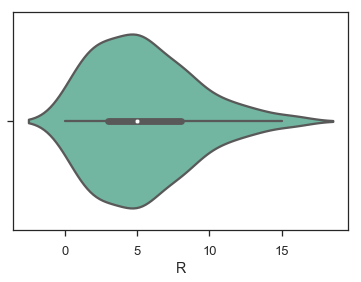

```python
ax = sns.violinplot(x="R",data=games1, palette="Set2")

#Matplotlib still underlies Seaborn, which means that the anatomy of the plot is still the
#same and that you’ll need to use plt.show() to make the image appear to you.

plt.show()


#https://seaborn.pydata.org/generated/seaborn.violinplot.html
```

### Swarmplot gives a better representation of the distribution of values, although it does not scale as well to large numbers of observations

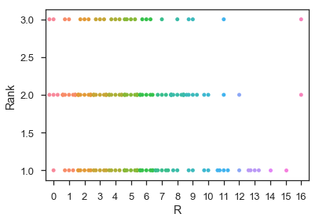

```python
sns.swarmplot(x="R", y="Rank", data=games1)
plt.show()

#https://seaborn.pydata.org/generated/seaborn.swarmplot.html
```

### A box plot (or box-and-whisker plot) shows the distribution of quantitative data in a way that facilitates comparisons between variables or across levels of a categorical variable.

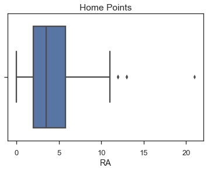

```python
ax = sns.boxplot(x="RA", data=games1)

#axis.set_title function is used to set a title for the graph

ax.set_title("Home Points")
plt.show()

#https://seaborn.pydata.org/generated/seaborn.boxplot.html
```

### A bar plot represents an estimate of central tendency for a numeric variable with the height of each rectangle and provides some indication of the uncertainty around that estimate using error bars.

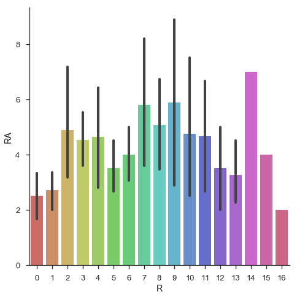

```python
#We will plot a bar graph of R and RA

g = sns.factorplot("R", "RA", data=games1, kind="bar", size=7, palette="hls", legend=False)

#axis.set function is used to set the limits for x and y axis

ax.set_xlim(0,15)
ax.set_ylim(0,15)

plt.show()

#https://seaborn.pydata.org/generated/seaborn.barplot.html
```